# Text Preparation in R and Python: Collaborative Workflow

QTA principles, cleaning, tokens, and document-feature matrices

Yen-Chieh Liao 廖彥傑

2026-09-18Last compiled: 2026-09-17 15:52:19 (Asia/Taipei)

## Learning objectives

**Week 2: Text Preparation in R and Python: Collaborative Workflow**

- Set up RStudio and Positron for text analysis with R and Python.
- Organize code with GitHub and submit written coursework through shared Overleaf projects.
- Inspect supplied corpora and check project data feasibility: coverage, metadata, and access.
- Clean and tokenize text, build a DFM, and evaluate preprocessing choices.

**Week 4 content introduced today:** Text preprocessing and document-feature matrices (DFMs). Week 4 builds on these with dictionaries, sentiment analysis, and validation.

Schoonvelde (2026); Welbers et al. (2017)

## Five principles of quantitative text analysis

1. **Domain knowledge** defines the research problem and relevant evidence.
2. **Human judgment** guides interpretation and validation.
3. **Discovery and testing** require distinct stages.
4. **The task** determines which methods are useful.
5. **Validation** evaluates whether the measure fits the claim.

Schoonvelde (2026); Grimmer et al. (2022)

## Selecting documents: Chapter 4 (Grimmer et al. 2022)

**Classroom example:** measuring expressed preference for coffee.

| Design choice | Example |
| --- | --- |
| Target population | Thai-language public posts about coffee in a specified month |
| Quantity of interest | Share of those posts expressing positive preference for coffee |
| Observed corpus | Posts returned by one platform API and a specified keyword search |

**Found data:** document how the texts were produced, preserved and retrieved.

The next step is to examine what the collection process leaves out.

Grimmer et al. (2022)

## Selection bias begins before preprocessing

| Source of bias | Example | Research consequence |
| --- | --- | --- |
| Resources | Well-funded groups archive more documents | Available texts overrepresent some actors |
| Incentives | Politicians publish strategically | Public statements differ from private beliefs |
| Medium | A platform limits length or visibility | The medium shapes expression |
| Retrieval | Searching only for “economy” | Relevant texts with other words disappear |

Schoonvelde (2026); Grimmer et al. (2022)

## Corpus boundaries and document units

| Decision | Example | What to record |
| --- | --- | --- |
| Population | Parliamentary speech contributions | Chamber, actors, dates |
| Inclusion | All contributions in selected debates | Rule and exclusions |
| Document unit | One contribution per row | How segments were defined |
| Identifier | A persistent `doc_id` | Links to source and metadata |

Changing the unit to speaker-day or party-year changes the comparison.

Schoonvelde (2026); Welbers et al. (2017)

## Sources and import routes

| Source | Typical route | First check |
| --- | --- | --- |
| Existing corpus | Download plus codebook | Coverage and sampling |
| TXT, CSV, TSV | `readr`, `data.table`, base R | Encoding and columns |
| JSON or API | `jsonlite`, `httr2` | Pagination and identifiers |
| HTML or XML | `rvest`, `xml2` | Boilerplate and structure |
| PDF or DOCX | `pdftools`, `readtext` | Reading order and document boundaries |

Scanned PDFs may need OCR before they contain usable text.

Schoonvelde (2026); Welbers et al. (2017)

## The R text-analysis toolkit in 2017

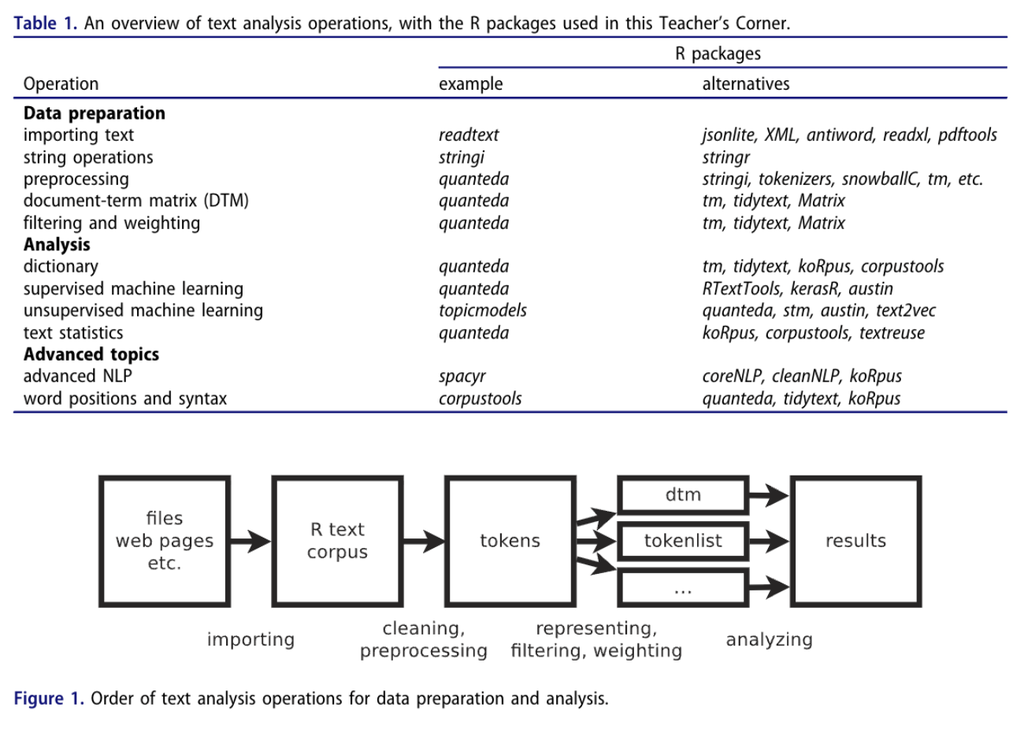

Historical package overview (2017). Package responsibilities and APIs have since changed.

Welbers et al. (2017)

## Beyond 2017: annotation and embeddings

| Tool / access from R | Model type | Output and use |
| --- | --- | --- |
| **UDPipe 1**: R `udpipe` | Supervised annotation pipeline trained on a treebank | Tokens, lemmas, POS, dependency labels |
| **UDPipe 2**: R + REST API | Neural annotation with contextual embeddings | Linguistic annotations; current models use BERT-based representations |
| **Flair**: R `reticulate` + Python (`flaiR`; Liao et al., 2023) | Contextual string embeddings or Transformer embeddings | Word/document vectors; models for NER, tagging and classification |

**FlairEmbeddings** uses character language models; **TransformerWordEmbeddings** uses models such as BERT.

R can prepare text, call these tools, and analyze the returned annotations or vectors.

Straka & Straková (2017); Straka (2018); Akbik et al. (2018, 2019); Liao et al. (2023)

## quanteda, UDPipe, spaCy, and Flair

| Tool / access | Main emphasis | Typical output |
| --- | --- | --- |
| **quanteda** (R) | Corpus management and feature analysis | Corpus, tokens, DFM; KWIC and TF-IDF |
| **UDPipe** (R / API) | Linguistic annotation using trained models | Tokens, lemmas, POS, UD dependency labels |
| **spaCy** (Python) | Configurable NLP pipelines | Tokens, POS, dependencies, named entities |
| **Flair** (Python) **flaiR**: R wrapper for Python Flair | Embeddings and neural task models | Vectors; entity labels, POS, text categories |

**The tools can work together:** lemmas or selected annotations can become features in a quanteda DFM.

Capabilities overlap and depend on the language, model, and task.

Benoit et al. (2018); Straka & Straková (2017); Explosion (n.d.); Akbik et al. (2019); Liao et al. (2023)

## Beyond 2017: R and Python in one workflow

**One possible application:** compare the meanings of policy statements.

| Stage | Example tools | Contribution |
| --- | --- | --- |
| Prepare in R | `stringr`, `quanteda` | Clean text and preserve document IDs |
| Represent in Python | `sentence-transformers` | Encode texts as semantic vectors |
| Evaluate in R | Statistical models and plots | Validate similarities and interpret patterns |

The languages can share a project. Each stage follows the research question.

Sentence Transformers contributors (n.d.); Ushey et al. (2026)

## Connecting R and Python

### Python inside an R session

- R’s **reticulate** package imports Python modules and calls their functions.
- I frequently used **reticulate** during my PhD (2018–2022).
- It converts supported objects between R and Python.
- Record the Python environment as well as R packages.

### Separate scripts, shared data

- R and Python scripts exchange files such as CSV or Parquet.
- A stable **document ID** connects inputs and outputs.
- Check row order, encoding and data types at each handoff.

An IDE organizes the work. Object or file exchange connects the languages.

Ushey et al. (2026); Posit (n.d.)

## Positron: one IDE for R and Python

In 2022, **RStudio the company became Posit**, reflecting its broader support for data science across languages.

- Posit developed **Positron** for multilingual data science.
- R and Python have built-in support, with consoles and data exploration.
- The **RStudio IDE** remains a separate, maintained product.

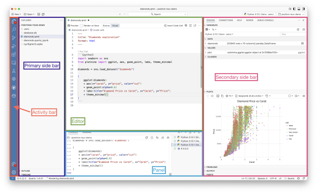

Our classroom examples use R.

Posit (2022, n.d.); Altman (2025)

## The sequence of text-analysis operations

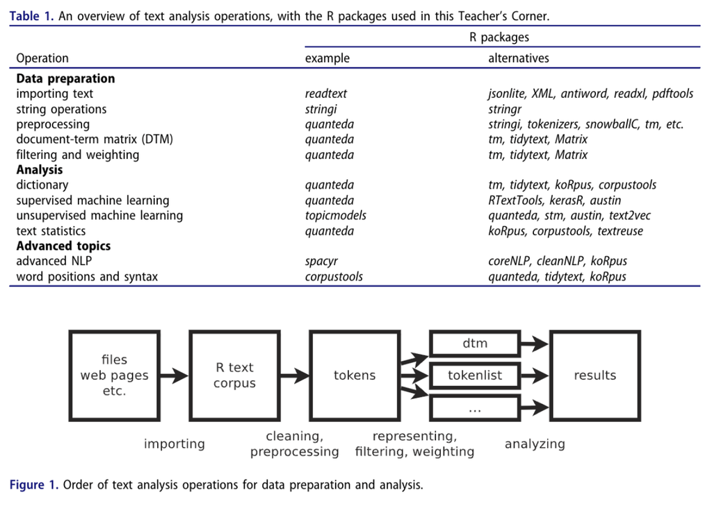

**The branch matters:** analysis can use a matrix, token positions, or other representations.

Welbers et al. (2017)

## Objects used in this session

| Object | Contents | Use |
| --- | --- | --- |
| Data frame | Text, identifiers, metadata | Import checks and joins |
| `corpus` | Text with document variables | Subsets and metadata access |
| `tokens` | Sequences of tokens | Phrase matching and context inspection |
| `dfm` | Documents × features | Counts and weighted representations |

`stringr` handles strings. `quanteda` provides the corpus, tokens, and DFM workflow.

Welbers et al. (2017); Schoonvelde (2026)

## Import checks and encoding

```r
texts <- readLines("data/speeches.txt", encoding = "UTF-8")
length(texts)
head(texts)
```

- Confirm the source encoding rather than guessing from appearance.
- Inspect accented characters and Chinese text after import.
- Count missing texts and duplicated identifiers.
- Check whether a row is a line, paragraph, or whole document.

A UTF-8 argument does not repair a wrongly identified source encoding.

Schoonvelde (2026); Welbers et al. (2017)

## A parliamentary example

| Field | Value in the source slide |
| --- | --- |
| Date | 1997-01-20 |
| Speaker | William Hague |
| Party | Conservative |
| Agenda | Public Expenditure [Oral Answers To Questions > Wales] |

Text includes **[Interruption.]**, **DRAMATICALLY**, and **!!!**.

Which elements are metadata, meaningful language, or recording conventions?

Schoonvelde (2026)

## Cleaning depends on the research question

| Element | Possible treatment | Information at stake |
| --- | --- | --- |
| Speaker and party | Store as metadata | Who speaks |
| `[Interruption.]` | Remove or extract into an indicator | Parliamentary interaction |
| Capitalization | Preserve or lowercase | Names and emphasis |
| Numbers | Keep, normalize, or remove | Years, budgets, percentages |
| Repeated punctuation | Preserve or simplify | Rhetorical emphasis |

Keep an untouched copy of the raw text.

Schoonvelde (2026); Welbers et al. (2017)

## String operations with stringr

| Function | Purpose | Example use |
| --- | --- | --- |
| `str_detect()` | Test whether a pattern appears | Flag bracketed annotations |
| `str_extract()` | Retrieve the first match | Extract a year |
| `str_remove_all()` | Remove all matches | Delete selected annotations |
| `str_replace_all()` | Replace matches | Standardize separators |
| `str_squish()` | Normalize whitespace | Remove repeated spaces |
| `str_to_lower()` | Change case | Merge case variants |

Schoonvelde (2026); Wickham (2025)

## Bracket patterns and unintended deletion

```r
s <- "Trade [Commons] and jobs [Wales]"

str_remove_all(s, "\\[.*\\]")
# "Trade "

str_remove_all(s, "\\[[^\\[\\]]*\\]") |> str_squish()
# "Trade and jobs"
```

The first pattern spans from the first `[` to the last `]`. The second handles separate, non-nested bracket groups.

Schoonvelde (2026); Wickham (2025)

## A cleaning example with an audit trail

```r
agenda_raw <- "  Export Trade [Commons] -- vol. 407  "
agenda_clean <- agenda_raw |>
  str_remove_all("\\[[^\\[\\]]*\\]") |>
  str_to_lower() |>
  str_replace_all("[^[:alnum:][:space:]]", " ") |>
  str_squish()
agenda_clean
```

```
[1] "export trade vol 407"
```

This rule preserves numbers and removes punctuation. Another task may need a different rule.

Schoonvelde (2026)

## A worked example: a small text corpus

| ID | Synthetic text |
| --- | --- |
| d1 | Health workers need health services. |
| d2 | The government supports health services. |
| d3 | Workers do not support the policy. |
| d4 | The government supports the policy. |

These short texts let us inspect every token and verify every count.

## Creating a corpus

```r
library(quanteda)

corp <- corpus(
  raw,
  docid_field = "doc_id",
  text_field = "text"
)

docnames(corp)
docvars(corp)
```

Each row supplies one text. The remaining columns become document variables.

Welbers et al. (2017); Schoonvelde (2026)

## Tokens, types, and vocabulary

Text: **“Health services need health workers.”**

| Representation | Tokens | Distinct types |
| --- | --- | --- |
| Case and punctuation retained | 6 | 6 |
| Lowercase, punctuation removed | 5 | 4 |

After normalization: `health`, `services`, `need`, `health`, `workers`

A **token** is an occurrence. A **type** is a distinct form under the chosen representation.

Schoonvelde (2026); Welbers et al. (2017)

## Tokens in R text analysis and LLMs

Both use **tokens**: units produced by tokenization for analysis or model processing.

| Comparison | Common R text-analysis workflow | Typical LLM workflow |
| --- | --- | --- |
| Common units | Words; optionally characters or sentences | Often subwords; can include whole words, characters or byte units |
| Segmentation depends on | Package, tokenizer and your settings | The model’s tokenizer and vocabulary |
| Main use | Word counts, DFM, TF-IDF, topic models | Token IDs used for model input and text generation |

**One word can become several LLM tokens.** R can call either kind of tokenizer; the workflow determines the unit.

Benoit et al. (2018); Wolf et al. (2020)

## Tokenizing with explicit choices

```r
toks <- tokens(corp, remove_punct = TRUE) |>
  tokens_tolower()

as.list(toks)[[1]]
```

```
[1] "health"   "workers"  "need"     "health"   "services"
```

Inspect the output when texts contain hyphens, URLs, abbreviations, or non-Latin scripts.

Schoonvelde (2026); Benoit et al. (2018)

## Preprocessing choices and information loss

| Choice | Possible benefit | Possible loss |
| --- | --- | --- |
| Lowercase | Merge `Health` and `health` | Proper-name distinctions |
| Remove stopwords | Reduce frequent function words | Negation or writing style |
| Stem or lemmatize | Merge some word forms | Differences in meaning |
| Trim rare features | Reduce vocabulary size | Rare but important concepts |

The relevant question is how the choice affects the intended measure.

Schoonvelde (2026); Welbers et al. (2017)

## Stopwords and negation

```r
sw <- setdiff(stopwords("en"), c("not", "no", "nor"))
toks_content <- tokens_remove(toks, pattern = sw)
```

| Rule applied to document d3 | Remaining tokens |
| --- | --- |
| Standard English stopword list | `workers support policy` |
| List that retains negation | `workers not support policy` |

Retaining `not` preserves a clue. A unigram model still needs a way to use its scope.

Schoonvelde (2026); Welbers et al. (2017)

## The bag-of-words representation

A DFM stores **one row per document** and **one column per feature**.

| ID | health | workers | government | policy | not |
| --- | --- | --- | --- | --- | --- |
| d1 | 2 | 1 | 0 | 0 | 0 |
| d2 | 1 | 0 | 1 | 0 | 0 |
| d3 | 0 | 1 | 0 | 1 | 1 |
| d4 | 0 | 0 | 1 | 1 | 0 |

Selected columns from our count DFM. Features can also represent phrases or other categories.

Schoonvelde (2026); Welbers et al. (2017)

## What word counts cannot recover

**“Workers support government.”**  
**“Government support workers.”**

The two sentences have the same lowercase unigram counts.

- Word order indicates who supports whom.
- Negation requires relationships between words.
- Ambiguous words need context.
- Sarcasm may depend on discourse beyond a sentence.

N-grams and syntax retain some additional information.

Schoonvelde (2026); Welbers et al. (2017)

## Multiword expressions

```r
phrase_toks <- tokens(
  "We support the armed forces.",
  remove_punct = TRUE
) |> tokens_tolower()

tokens_compound(
  phrase_toks,
  pattern = phrase("armed forces")
)
```

`armed_forces` becomes a single feature. Detect phrases before removing words that belong inside them.

Schoonvelde (2026); Welbers et al. (2017)

## Bigrams and operation order

```r
tokens("Workers do not support the policy.",
       remove_punct = TRUE) |>
  tokens_tolower() |>
  tokens_ngrams(n = 2)
```

`workers_do`, `do_not`, `not_support`, `support_the`, `the_policy`

Generate these before stopword removal if original adjacency matters. Deleting words first can create pairs that were never adjacent.

Schoonvelde (2026); Welbers et al. (2017)

## Collocations and grammatical features

| Feature strategy | Example | Required judgment |
| --- | --- | --- |
| Known phrase | `armed_forces` | Which phrases matter? |
| Statistical collocation | Candidate such as `northern_ireland` | Is association substantively useful? |
| POS selection | Nouns, verbs, adjectives | Which grammatical roles fit the task? |

A frequent or associated word pair is a candidate feature. Inspect its uses before adding it to the measurement rule.

Schoonvelde (2026); Welbers et al. (2017)

## Stemming and lemmatization

| Method | Example | Limitation |
| --- | --- | --- |
| Stemming | `studies` becomes `studi` | Stems may not be dictionary words |
| Lemmatization | `studies` may become `study` | Accuracy depends on language and context |
| Explicit replacement | Map `forces` to `force` | Only the supplied mapping is handled |

Neither approach guarantees correct semantic grouping. A dictionary built from full words may fail to match stemmed features.

Schoonvelde (2026); Welbers et al. (2017)

## Language and model requirements

### Language

- English whitespace is not a universal word boundary.
- Chinese segmentation needs inspection.
- Stopword and morphology tools are language specific.

### Model

- A DFM may use word or phrase features.
- A pretrained model expects its own tokenizer.
- Preserve the input distinctions that model requires.

A BoW preprocessing recipe should not automatically become an LLM input recipe.

Schoonvelde (2026); Welbers et al. (2017)

## UDPipe models: Japanese, Chinese, and Thai

| Input language | Access from R | Model |
| --- | --- | --- |
| Japanese | `udpipe`: local UDPipe 1 | `japanese-gsd` (UD 2.5) |
| Traditional Chinese | `udpipe`: local UDPipe 1 | `chinese-gsd` (UD 2.5) |
| Thai | `httr2`: UDPipe 2 API | `thai-tud` (UD 2.17) |

- All three provide segmented `token` and predicted `upos` (POS).
- Dependency parsing adds heads and relation labels.
- `lemma` is a predicted base form; this Thai model returns `_` (unavailable).

**Instructor demonstration:** interpret the prepared model outputs shown in these slides.

Wijffels & Straka (2026); Straka (2018); Universal Dependencies contributors (n.d.)

## Annotating UTF-8 text with UDPipe

```r
library(udpipe)
# Set model_path to a downloaded Chinese-GSD model.
zh_model <- udpipe_load_model(model_path)
ann_zh <- udpipe_annotate(zh_model, x = "我喜歡咖啡。",
  doc_id = "zh_coffee", parser = "default") |> as.data.frame()
ann_zh[c("token_id", "token", "upos",
         "head_token_id", "dep_rel")]
```

Chinese: `chinese-gsd`; English: `english-ewt`; Thai: R + UDPipe 2 API.

- `parser = "default"` adds dependency parsing to tokens and POS.
- `head_token_id` identifies the head; `dep_rel` labels the relationship. Head `0` marks the sentence root.

Wijffels & Straka (2026); Universal Dependencies contributors (n.d.)

## Word tokenization across languages

Same meaning: “I like coffee.”

### Thai

R: httr2 + UDPipe 2 API

ฉันชอบกาแฟ

Tokens (POS)

ฉัน (PRON)  
ชอบ (VERB)  
กาแฟ (NOUN)

**3 tokens**

The Thai model finds word boundaries.

### Japanese

R: udpipe (japanese-gsd)

私はコーヒーが好きです。

Tokens (POS)

私 (PRON) / は (ADP)  
コーヒー (NOUN) / が (ADP)  
好き (ADJ) / です (AUX)

**6 tokens**

Particles and auxiliaries remain separate tokens.

### Chinese

R: udpipe (chinese-gsd)

我喜歡咖啡。

Tokens (POS)

我 (PRON)  
喜歡 (VERB)  
咖啡 (NOUN)

**3 tokens**

Multi-character words can form single tokens.

POS = part of speech. Counts exclude punctuation.

Straka & Straková (2017); Straka (2018)

## Dependency labels across languages

Same meaning: “I like coffee.”

### Chinese (Traditional)

R: udpipe (chinese-gsd)

我喜歡咖啡。

| Token (POS) | dep_rel |
| --- | --- |
| 1 我 (PRON) | nsubj |
| 2 喜歡 (VERB) | root |
| 3 咖啡 (NOUN) | obj |

Head IDs: 2 / 0 / 2

### English

R: udpipe (english-ewt)

I like coffee.

| Token (POS) | dep_rel |
| --- | --- |
| 1 I (PRON) | nsubj |
| 2 like (VERB) | root |
| 3 coffee (NOUN) | obj |

Head IDs: 2 / 0 / 2

### Thai

R: httr2 + UDPipe 2 API

ฉันชอบกาแฟ

| Token (POS) | dep_rel |
| --- | --- |
| 1 ฉัน (PRON) | nsubj |
| 2 ชอบ (VERB) | root |
| 3 กาแฟ (NOUN) | obj |

Head IDs: 2 / 0 / 2

**nsubj** = nominal subject; **root** = sentence root; **obj** = object.

Head 0 marks the root; other IDs point to a token in the same sentence.

Punctuation is omitted from this display.

Straka & Straková (2017); Straka (2018); Universal Dependencies contributors (n.d.)

## Japanese: observed segmentation

**政府は医療従事者を支援する。**

| ID | token | lemma | upos | head | dep_rel |
| --- | --- | --- | --- | --- | --- |
| 1 | 政府 | 政府 | NOUN | 6 | nsubj |
| 2 | は | は | ADP | 1 | case |
| 3 | 医療 | 医療 | NOUN | 4 | compound |
| 4 | 従事者 | 従事者 | NOUN | 6 | obj |
| 5 | を | を | ADP | 4 | case |
| 6 | 支援 | 支援 | VERB | 0 | root |
| 7 | する | する | AUX | 6 | aux |
| 8 | 。 | 。 | PUNCT | 6 | punct |

**Dependency parsing:** `head` = head token ID (0 = root); `dep_rel` = relation.

Straka & Straková (2017)

## Traditional Chinese: observed segmentation

**政府支持醫療工作者。**

| ID | token | lemma | upos | head | dep_rel |
| --- | --- | --- | --- | --- | --- |
| 1 | 政府 | 政府 | NOUN | 5 | nmod |
| 2 | 支持 | 支持 | NOUN | 5 | nmod |
| 3 | 醫療 | 醫療 | NOUN | 5 | nmod |
| 4 | 工作 | 工作 | VERB | 5 | compound |
| 5 | 者 | 者 | PART | 0 | root |
| 6 | 。 | 。 | PUNCT | 5 | punct |

**Dependency parsing:** `head` = head token ID (0 = root); `dep_rel` = relation.

**Model errors:** 支持 is tagged `NOUN`; 者 is predicted as `root`. Inspect the original sentence before interpreting these outputs.

Straka & Straková (2017); Universal Dependencies contributors (n.d.)

## Negation and POS-based feature selection

**政府不支持刪減醫療預算。**

| ID | token | lemma | upos | head | dep_rel |
| --- | --- | --- | --- | --- | --- |
| 1 | 政府 | 政府 | NOUN | 3 | nsubj |
| 2 | 不 | 不 | ADV | 3 | advmod |
| 3 | 支持 | 支持 | VERB | 0 | root |
| 4 | 刪減 | 刪減 | VERB | 3 | xcomp |
| 5 | 醫療 | 醫療 | NOUN | 6 | nmod |
| 6 | 預算 | 預算 | NOUN | 4 | obj |
| 7 | 。 | 。 | PUNCT | 3 | punct |

**Dependency parsing:** `head` = head token ID (0 = root); `dep_rel` = relation.  
Keeping only `NOUN` and `VERB` removes **不** (`ADV`), attached to **支持** (ID 3) by `advmod`. The feature list loses negation.

Straka & Straková (2017)

## From Thai syntax to a research measure

ฉันชอบกาแฟ “I like coffee.”

### Dependency relations

[figure not shown]

Arrows run from head to dependent.

- **Language relationships**  
  POS marks word classes. Dependencies link a subject to a predicate and target.
- **Operationalize preference**  
  Link the subject to “like” and its object. Check that the statement is affirmative.
- **Code this example**  
  Coffee: positive preference = 1.
- **Research question**  
  Which targets receive more expressions of positive preference?

Corpus measure: share of documents mentioning a target that express positive preference.

Straka (2018); Universal Dependencies contributors (n.d.)

## UDPipe annotations as quanteda tokens

```r
# Assume ann_multi contains an annotation table.
a <- subset(ann_multi, upos != "PUNCT")
a <- a[order(a$doc_id, a$sentence_id,
             as.integer(a$token_id)), ]

ja_tokens <- split(a$token[a$doc_id == "ja_01"],
                   a$doc_id[a$doc_id == "ja_01"])
ja_dfm <- dfm(as.tokens(ja_tokens), tolower = FALSE)
```

Use `as.tokens()` to preserve the existing segmentation. Build the Chinese DFM from the Chinese documents in the same way.

Code illustration: annotations → tokens → DFM.

Benoit et al. (2018); Wijffels & Straka (2026)

## Tokens become DFM features

[figure not shown]

Benoit et al. (2018)

## Building and inspecting the DFM

```r
x <- dfm(toks_content)
dim(x)
topfeatures(x, 6)
```

```
[1] 4 9
```

```
    health    workers   services government   supports     policy
         3          2          2          2          2          2
```

Rows retain the document IDs. The full DFM includes features beyond the selected columns shown earlier.

Schoonvelde (2026); Welbers et al. (2017)

## Term frequency and document frequency

| Feature | Total occurrences | Documents containing it |
| --- | --- | --- |
| `health` | 3 | 2 |
| `workers` | 2 | 2 |
| `not` | 1 | 1 |

```r
docfreq(x)
x_trim <- dfm_trim(x, min_docfreq = 2,
                  docfreq_type = "count")
```

This threshold removes `not`. A rare feature can still carry essential meaning.

Schoonvelde (2026); Welbers et al. (2017)

## Counts, binary indicators, and TF-IDF

| Representation | Meaning of a cell | Possible use |
| --- | --- | --- |
| Count | Number of occurrences | Frequency-based measurement |
| Binary | Whether the feature appears | Presence-based comparison |
| TF-IDF | Count adjusted for corpus prevalence | Document retrieval or comparison |

The choice changes what repeated words contribute. Model requirements may constrain which representation is appropriate.

Schoonvelde (2026); Welbers et al. (2017)

## TF-IDF with a stated formula

For this lesson, use raw counts and a base-10 logarithm:

TF-IDF(d, t) = count(d, t) × log₁₀(N / df(t))

- **N** is the number of documents in the reference corpus.
- **df(t)** counts documents that contain feature *t*.
- A feature in every document receives IDF = 0 under this formula.

Different normalizations and smoothing rules produce different weights.

Schoonvelde (2026); Benoit et al. (2018)

## TF-IDF in the worked example

For `health`, **N = 4**, **df = 2**, so IDF = log₁₀(2) ≈ **0.3010**.

| Document | Count of `health` | TF-IDF |
| --- | --- | --- |
| d1 | 2 | 0.6021 |
| d2 | 1 | 0.3010 |
| d3 | 0 | 0 |
| d4 | 0 | 0 |

```r
x_weighted <- dfm_tfidf(x, scheme_tf = "count",
                      scheme_df = "inverse", base = 10)
```

Benoit et al. (2018)

## Context checks with KWIC

```r
kwic(toks, pattern = "support*", window = 3)
```

| docname | pre | keyword | post |
| --- | --- | --- | --- |
| d2 | the government | supports | health services |
| d3 | workers do not | support | the policy |
| d4 | the government | supports | the policy |

Read the context around a matched term before treating its count as support for a policy.

Welbers et al. (2017); Benoit et al. (2018)

## Wrap-up: DFM, KWIC, TF-IDF

| Tool | What it lets you do |
| --- | --- |
| **DFM** | Represent document features for comparison and modeling. |
| **KWIC** | Read terms in context and check what feature counts mean. |
| **TF-IDF** | Emphasize distinctive terms for retrieval and similarity. |

**Wordfish** is an unsupervised method for scaling texts on **one dimension**.

Word-count DFM → e.g., Wordfish → relative document positions

**Use:** compare party manifestos or speeches. **Input:** counts, not TF-IDF weights.  
Interpret and validate the scale before calling it ideology.

Benoit et al. (2018); Slapin & Proksch (2008); Lowe & Benoit (2013)

## Sensitivity to preprocessing

| Compare | Inspect | Explain |
| --- | --- | --- |
| With / without stopwords | Negation and grammatical context | Which distinctions vanish? |
| Unigrams / phrases | Compound concepts | Which matches change? |
| Full / trimmed vocabulary | Removed features and empty rows | Which documents lose evidence? |
| Counts / TF-IDF | Relative feature contributions | Does the result depend on weighting? |

Keep the corpus and research question fixed while comparing a chosen rule.

Schoonvelde (2026); Welbers et al. (2017)

## In-class setup: install, open, run

**Download and install:** [R](https://cran.r-project.org/) and [Python 3](https://www.python.org/downloads/), then [RStudio Desktop](https://docs.posit.co/ide/user/#rstudio-ide) and [Positron](https://positron.posit.co/download).

**Try the consoles:** `1 + 1` in R; `print(1 + 1)` in Python. Both return `2`.

**Open** `Lab_Session_W2.R` in `lab/`. In the **R console**, install:

```r
install.packages(c("dplyr", "stringr", "ggplot2",
  "quanteda", "quanteda.textstats", "quanteda.textplots"))
```

Set the working directory to `W2/lab/`. Keep its `Data/` folder alongside the script. Run the lab section by section at home.

**Take-home skill:** Open an `.R` file in RStudio or Positron and run the lab independently.

R Core Team (n.d.); Python Software Foundation (n.d.); Posit (n.d.)

## Take-home lab

**Complete independently at home.** Use the supplied sample of **5,000 House of Commons speech contributions (1945–2025)**.

1. Inspect strings and clean agenda metadata with `stringr`.
2. Build, subset, and reshape a `quanteda` corpus.
3. Tokenize, preserve phrases, and inspect KWIC contexts.
4. Build and trim DFMs; explore frequencies, plots, and keyness.
5. Work through the **11 practice exercises** in the lab.

Folder: `lab/`  
Open `Lab_Session_W2.qmd` or its `.R` companion. Data are included.

Schoonvelde (2026)

## Take-home practice and support

- Run the worked examples **section by section** and inspect each output.
- Attempt all **11 exercises** and save your code and questions.
- Bring the exercise number, relevant code, and output or error message.
- Discuss questions **before class, if time permits**, or ask during **TA hours**.

Be ready to explain what your code changes and how that affects the evidence.

## Discussion and answer guide

**Why can deleting a common word damage a measure?**  
A word such as `not` can determine the meaning of the surrounding statement.

**Why does document frequency change after aggregation?**  
Its value depends on what counts as one document.

**Does successful preprocessing validate a substantive claim?**  
It validates an implementation only in limited ways. The measure still needs evidence appropriate to the research question.

Schoonvelde (2026); Welbers et al. (2017)

## Readings and software references

**Primary lecture source**  
Schoonvelde, M. (2026). *Quantitative text analysis – Essex Summer School: Principles of QTA, cleaning text, and preprocessing text*. Supplied slides, 38 pages.

**Reading and reproduced figure/table**  
Welbers, K., Van Atteveldt, W., & Benoit, K. (2017). *Text Analysis in R*. Communication Methods and Measures, 11(4), 245–265. [doi:10.1080/19312458.2017.1387238](https://doi.org/10.1080/19312458.2017.1387238).

**Corpus selection reading**  
Grimmer, J., Roberts, M. E., & Stewart, B. M. (2022). *Text as Data: A New Framework for Machine Learning and the Social Sciences*. Princeton University Press. Chapter 4: “Selecting Documents.” [Book](https://press.princeton.edu/books/hardcover/9780691207544/text-as-data).

**Software documentation**  
[quanteda: tokens](https://quanteda.io/reference/tokens.html), [TF-IDF](https://quanteda.io/reference/dfm_tfidf.html), [KWIC](https://quanteda.io/reference/kwic.html), [stringr: pattern removal](https://stringr.tidyverse.org/reference/str_remove.html).

[UDPipe guide](https://bnosac.github.io/udpipe/docs/doc2.html), [Japanese GSD](https://universaldependencies.org/treebanks/ja_gsd/index.html), [Chinese GSD](https://universaldependencies.org/treebanks/zh_gsd/index.html).

The English, Thai, Japanese, and Chinese texts are synthetic teaching examples.